# Day 3: deep learning

Seth Flaxman

4 July 2019

Today you will build a number of neural networks, starting with no hidden layers (equivalent to the linear model), then adding a few fully connected hidden layers (sometimes called the “multilayer perceptron”), then trying out a convolution neural network formulation.

You will need to install Keras. Follow instructions here https://keras.rstudio.com or try the following:

```
devtools::install_github("rstudio/keras") # if this doesn't work, first install devtools: install.packages("devtools")
library(keras)
install_keras()
```

Keras comes with the MNIST dataset that you saw on day 1. You can access it as follows:

```r
library(keras)
mnist <- dataset_mnist()
x_train <- mnist$train$x
y_train <- mnist$train$y
x_test <- mnist$test$x
y_test <- mnist$test$y
```

Following (https://keras.rstudio.com/) we will preprocess a little differently than we did on day 1.

```r
# reshape
x_train <- array_reshape(x_train, c(nrow(x_train), 784))
x_test <- array_reshape(x_test, c(nrow(x_test), 784))
# rescale
x_train <- x_train / 255
x_test <- x_test / 255
```

Now we are ready to define our neural network architecture. We will start with a linear model, connecting the 28x28 matrix of inputs to a single outputs unit. We will also have a bias term.

```r
model <- keras_model_sequential()
model %>% layer_dense(units = 1, input_shape = c(784), activation = 'linear')
summary(model)
```

```
## ___________________________________________________________________________
## Layer (type)                     Output Shape                  Param #
## ===========================================================================
## dense_1 (Dense)                  (None, 1)                     785
## ===========================================================================
## Total params: 785
## Trainable params: 785
## Non-trainable params: 0
## ___________________________________________________________________________
```

- Why are there 785 parameters total?
- Recall that this linear model isn’t actually a sensible approach! (Why?)

Let us try training:

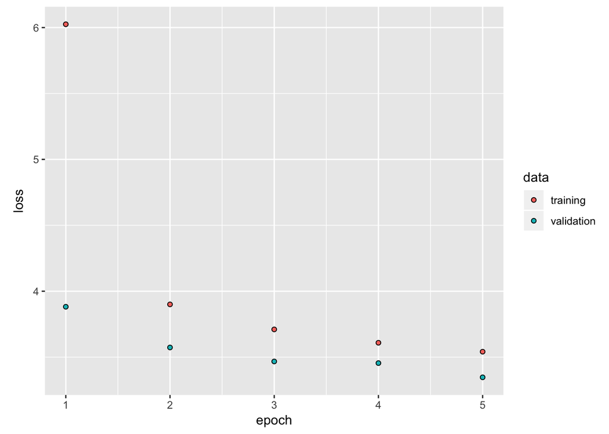

```r
model %>% compile(
  loss = 'mean_squared_error',
  optimizer = optimizer_rmsprop()
)
history <- model %>% fit(
  x_train, y_train,
  epochs = 5, batch_size = 128,
  validation_split = 0.2
)
plot(history)
```

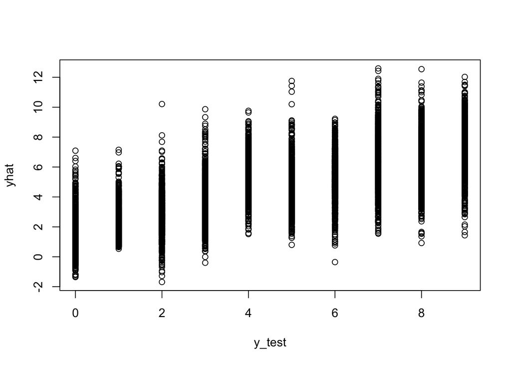

```r
## we can graphically see that our model is not doing a good job:
yhat = model %>% predict(x_test)
plot(y_test,yhat)
```

```r
mean(y_test == as.numeric(round(yhat))) # very low accuracy
```

```
## [1] 0.2301
```

Let us now switch to a more sensible model: instead of 1 output unit, we will have 10, one per class. We will need a softmax activation function.

```r
y_train <- to_categorical(mnist$train$y, 10)
y_test <- to_categorical(mnist$test$y, 10)

model2 <- keras_model_sequential()
model2 %>% layer_dense(units = 10, input_shape = c(784), activation = 'softmax')
summary(model2)
```

```
## ___________________________________________________________________________
## Layer (type)                     Output Shape                  Param #
## ===========================================================================
## dense_2 (Dense)                  (None, 10)                    7850
## ===========================================================================
## Total params: 7,850
## Trainable params: 7,850
## Non-trainable params: 0
## ___________________________________________________________________________
```

- Why are there 7850 parameters now?

Instead of squared error loss, we will minimize the multiclass version of LogLoss, often called cross-entropy:

```r
model2 %>% compile(
  loss = 'categorical_crossentropy',
  optimizer = optimizer_rmsprop(),
  metrics = c('accuracy')
)
history <- model2 %>% fit(
  x_train, y_train,
  epochs = 5, batch_size = 128,
  validation_split = 0.2
)
```

Now we can check that our accuracy is much higher:

```r
model2 %>% evaluate(x_test, y_test)
```

```
## $loss
## [1] 0.2815227
##
## $acc
## [1] 0.921
```

- Try training for more epochs to see if you get higher test accuracy. Do you notice overfitting?
- Consider training a multilayer perceptron. Belowis code for one layer, but you should also experiment with two or three, of varying widths:

```
model3 <- keras_model_sequential()
model3 %>%
  layer_dense(units = 256, activation = 'relu', input_shape = c(784)) %>%
  layer_dense(units = 10, activation = 'softmax')
```

- Consider adding convolution layers. You will need to reshape the data slightly. Here is code with two convolution layers to get you started:

```
img_rows = img_cols = 28
x_train <- array_reshape(mnist$train$x, c(nrow(mnist$train$x), img_rows, img_cols, 1))
x_test <- array_reshape(mnist$test$x, c(nrow(mnist$test$x), img_rows, img_cols, 1))
input_shape <- c(img_rows, img_cols, 1)

model <- keras_model_sequential() %>%
  layer_conv_2d(filters = 2, kernel_size = c(3,3), activation = 'relu',
                input_shape = input_shape) %>%
  layer_conv_2d(filters = 4, kernel_size = c(3,3), activation = 'relu') %>%
  layer_flatten() %>%
  layer_dense(units = 128, activation = 'relu') %>%
  layer_dense(units = 10, activation = 'softmax')
summary(model)
# Train model
model %>% compile(
  loss = 'categorical_crossentropy',
  optimizer = optimizer_rmsprop(),
  metrics = c('accuracy')
)
history <- model %>% fit(
  x_train, y_train,
  epochs = 5, batch_size = 128,
  validation_split = 0.2
)
model %>% evaluate(x_test, y_test)
```

- Can you get the accuracy above 99%? You might consider adding dropout layers (`keras.layers.Dropout`) or weight decay (`kernel_regularizer = regularizer_l2(l = 0.001)`).

## Deep learning with the mouse genome

- Consider the mouse genome dataset from yesterday. Build a neural network for this data. Consider varying any or all of the following:
- Number of hidden layers
- Activation functions
- Methods for regularization (dropout, weight decay, early stopping)
- Number of hidden units You might also want to consider a convolution neural network operating in 1-dimension using `layer_conv_1d`.

Train your network using `X_train`/`y_train`. Test your network using `X_test`/`y_test` from `data/mice.rdata`.

I have also included `X_validate`, but not `y_validate`. Once you think you have a good model, make predictions on `X_validate` and submit to this Dropbox link: https://www.dropbox.com/request/5V1NRSFTI2wARHiYy62d (DEADLINE 23:00 4 July 2019.)

You should save your prediction using the following function so that I can automatically score them:

```r
submit_answers = function(yhat,team="Pick a nickname for yourself or team; should not contain spaces or special characters") {
  team = gsub("[[:punct:]]", "", team)
  team = gsub(" ", "", team, fixed = TRUE)

  if(length(yhat) == 153 & class(yhat) == "numeric") {
    id = round(abs(sum(yhat)*1000))
    print(sprintf("Saving %s-%d.csv",team,id))
    df = data.frame(yhat=yhat,team=team)
    write.csv(df,sprintf("%s-%d.csv",team,id),row.names=F)
  } else {
    print("Something went wrong. You should supply a numeric vector yhat of length 153 containing your predictions.")
  }
}
submit_answers(rnorm(153),"random-submission")
```

```
## [1] "Saving randomsubmission-23988.csv"
```